# Trees

### Data and Computing Fundamentals

You may have seen an evolutionary tree like this one of mammals:

[figure not shown]

We humans ([hominidae](http://en.wikipedia.org/wiki/Hominidae)) are on the far left of the tree. The numbers at the branch points are estimates of how long ago — in millions of years — the branches separated. According to the diagram, rodents and we primates diverged about 90 million years ago.

The tree, sometimes called a **dendrogram**, is a nice organizing structure for relationships. In biology, we imagine that at each branch point there was an actual animal whose descendents split into groups that developed in different directions. In evolutionary biology, the inferences about branches come from comparing existing creatures to one another (as well as creatures from the fossil record). Creatures with similar traits are in nearby branches, creatures with different traits are in further branches. It takes considerable expertise in anatomy and morphology to know what similarities and differences to look for.

Trees can describe degrees of similarity between different things, regardless of how those relationships came to be. If you have a set of objects or cases, and you can measure how similar any two of the objects are, you can construct a tree. The tree may or may not reflect some deeper relationship among the objects, but it often provides a simple way to visualize relationships.

When the description of an object consists of a set of numerical variables, there are two main steps in constructing a tree:

1. Represent each object as a point in a Cartesian space.
2. Make branching decisions based on how close together points or clouds of points are.

The data about automobile characteristics in `mtcars` can illustrate.

```r
data(mtcars)
names(mtcars)
```

```
##  [1] "mpg"  "cyl"  "disp" "hp"   "drat" "wt"   "qsec" "vs"   "am"   "gear"
## [11] "carb"
```

```r
summary(mtcars)
```

```
##       mpg            cyl            disp             hp
##  Min.   :10.4   Min.   :4.00   Min.   : 71.1   Min.   : 52.0
##  1st Qu.:15.4   1st Qu.:4.00   1st Qu.:120.8   1st Qu.: 96.5
##  Median :19.2   Median :6.00   Median :196.3   Median :123.0
##  Mean   :20.1   Mean   :6.19   Mean   :230.7   Mean   :146.7
##  3rd Qu.:22.8   3rd Qu.:8.00   3rd Qu.:326.0   3rd Qu.:180.0
##  Max.   :33.9   Max.   :8.00   Max.   :472.0   Max.   :335.0
##       drat            wt            qsec            vs
##  Min.   :2.76   Min.   :1.51   Min.   :14.5   Min.   :0.000
##  1st Qu.:3.08   1st Qu.:2.58   1st Qu.:16.9   1st Qu.:0.000
##  Median :3.69   Median :3.33   Median :17.7   Median :0.000
##  Mean   :3.60   Mean   :3.22   Mean   :17.8   Mean   :0.438
##  3rd Qu.:3.92   3rd Qu.:3.61   3rd Qu.:18.9   3rd Qu.:1.000
##  Max.   :4.93   Max.   :5.42   Max.   :22.9   Max.   :1.000
##        am             gear           carb
##  Min.   :0.000   Min.   :3.00   Min.   :1.00
##  1st Qu.:0.000   1st Qu.:3.00   1st Qu.:2.00
##  Median :0.000   Median :4.00   Median :2.00
##  Mean   :0.406   Mean   :3.69   Mean   :2.81
##  3rd Qu.:1.000   3rd Qu.:4.00   3rd Qu.:4.00
##  Max.   :1.000   Max.   :5.00   Max.   :8.00
```

```r
carDiffs = dist(mtcars)
```

The result gives the “distance” from each individual car to every other car. It's much like the tables that used to be printed on road maps giving the distance from one city to another, like this one of European cities:

[figure not shown]

Notice that the distances are symmetrical: it's the same distance from Barcelona to Amsterdam as from Amsterdam to Barcelona (1620 km, according to the table).

Knowing the distances between the cities is not the same thing as knowing their locations. But the set of mutual distances is enough information to reconstruct the relative positions.

Cities, of course, lie on the surface of the earth. That need not be true for the abstract distance between automobile types. Even so, the set of mutual distances provides information equivalent to knowing the relative positions. This can be used to construct branches between nearby items, then to connect those branches, and so on to construct an entire tree. The process is called “hierarchical clustering.” For example:

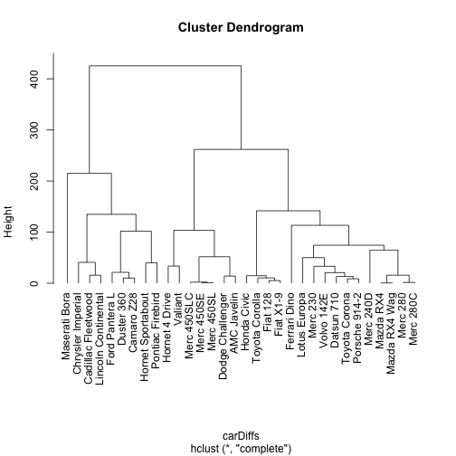

```r
hc = hclust(carDiffs)
plot(hc, hang = -1)
```

Performance-related measures

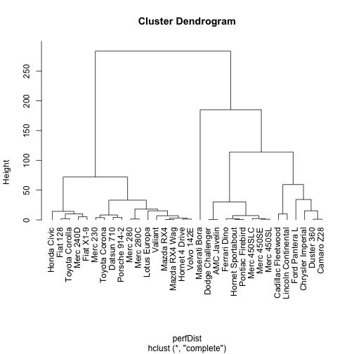

```r
perfDist = dist(getVarFormula(~mpg + hp + wt + qsec, data = mtcars))
hc = hclust(perfDist)
plot(hc, hang = -1)
```

There are many ways to graph such trees. For examples, see [Visualizing Dendrograms in R](http://rpubs.com/gaston/dendrograms).

EXERCISE:

Here are commands for grabbing Gapminder data on some variables relating to support for women.

```r
varNames = c("MarriageAgeFemale", "ContraceptiveUse", "Alcohol", "Fertility",
    "PrimaryEdCompletionFemale")
res = NULL  # start with no data
for (XXX in varNames) {
    gapdat = fetchGapminder(paste("Gapminder/", XXX, ".csv", sep = ""))
    gapdat = subset(gapdat, Year >= 2000)
    command = parse(text = paste("mean(", XXX, ")"))
    oneVar = groupBy(gapdat, by = Country, value = eval(command))
    oneVar = rename(oneVar, c(value = XXX))
    # Outer join with existing data
    if (is.null(res)) {
        res = oneVar
    } else {
        res = join(res, oneVar, by = "Country", type = "full")
    }
}
```

```
## Retrieving from
## http://www.mosaic-web.org/go/datasets/Gapminder/MarriageAgeFemale.csv
```

```
## Retrieving from
## http://www.mosaic-web.org/go/datasets/Gapminder/ContraceptiveUse.csv
```

```
## Retrieving from
## http://www.mosaic-web.org/go/datasets/Gapminder/Alcohol.csv
```

```
## Retrieving from
## http://www.mosaic-web.org/go/datasets/Gapminder/Fertility.csv
```

```
## Retrieving from
## http://www.mosaic-web.org/go/datasets/Gapminder/PrimaryEdCompletionFemale.csv
```

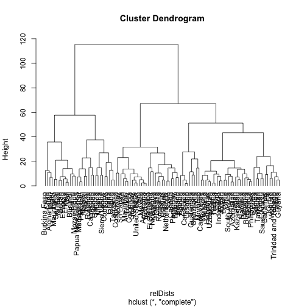

```r
ress = subset(res, complete.cases(res))
relDists = dist(getVarFormula(Country ~ ., data = ress))
hc = hclust(relDists)
plot(hc, hang = -1)
```